# Homework 3

# Preliminaries

- This file should be in `STAT240/homework/hw03` on your local computer.
- You should also download `exoplanets-clean-through-2022.csv` to `STAT240/data` on your local computer.

# Problem 1

The columns `mass` and `radius` are relative to Earth. A mass or radius of 2.0 refers to a planet twice the mass or radius of Earth. A mass or radius of 0.5 refers to a planet half the mass or radius of Earth.

Starting from `planets`,

- Keep only the planets whose `mass` AND `radius` are smaller than those of Earth’s.
- Get rid of the columns `id` and `star`.
- Sort the rows increasing by `mass`; the smallest mass should be the first row, and the largest mass should be the last row.
- Save this dataframe as some name other than `planets`, and then in a separate line print the entire resulting table, using `print()` with the `n = Inf` argument.

```r
problem_1 <- planets %>%
  filter(mass < 1 & radius < 1) %>%
  select(-id, -star) %>%
  arrange(mass)

print(problem_1, n = Inf)
```

```
## # A tibble: 11 × 5
##    planet       method                         year radius  mass
##    <chr>        <chr>                         <dbl>  <dbl> <dbl>
##  1 Kepler-138 b Transit                        2014  0.64  0.07
##  2 TRAPPIST-1 h Transit                        2017  0.755 0.326
##  3 LHS 1678 b   Transit                        2021  0.696 0.35
##  4 TRAPPIST-1 d Transit                        2016  0.788 0.388
##  5 L 98-59 b    Transit                        2019  0.85  0.4
##  6 KOI-55 b     Orbital Brightness Modulation  2011  0.759 0.44
##  7 GJ 367 b     Transit                        2021  0.718 0.546
##  8 HD 23472 d   Transit                        2022  0.75  0.55
##  9 KOI-55 c     Orbital Brightness Modulation  2011  0.867 0.655
## 10 TRAPPIST-1 e Transit                        2017  0.92  0.692
## 11 HD 23472 e   Transit                        2022  0.818 0.72
```

# Problem 2

Starting from `planets`:

- Keep only planets discovered by the `method` “Radial Velocity”.
- Keep only rows whose `mass` and `radius` are both known. (e.g. they are not missing.)
- `group_by` and `summarize` the data, such that:
  - You get one row per year.
  - You create the columns `n_discovered` and `minimum_mass`, which contain the number of planets discovered in that year, and the smallest mass among planets discovered in that year.
- Save this dataframe with the name `mass_by_year`. Then, on a separate line, let `mass_by_year` be shown as output so we can see the first ten rows in your knitted file.

```r
mass_by_year <- planets %>%
  filter(method == "Radial Velocity") %>%
  drop_na(radius, mass) %>%
  group_by(year) %>%
  summarize(n_discovered = n(),
            minimum_mass = min(mass))

mass_by_year
```

```
## # A tibble: 12 × 3
##     year n_discovered minimum_mass
##    <dbl>        <int>        <dbl>
##  1  1999            1       232.
##  2  2001            1      1392.
##  3  2004            2         7.99
##  4  2005            2       121.
##  5  2007            1      1116.
##  6  2010            1         8.3
##  7  2012            1        13.9
##  8  2015            4         4.36
##  9  2019            3         4.72
## 10  2020            1        42.4
## 11  2021            2         2.82
## 12  2022            1      2543.
```

Your first two rows should look like this if you did it correctly:

```
    year n_discovered minimum_mass
   <dbl>        <int>        <dbl>
 1  1999            1       232.
 2  2001            1      1392.
```

# Problem 3

Using `mass_by_year` from the previous problem, create a scatter plot of `minimum_mass` on the y axis versus `year` on the x axis.

Incorporate the following customizations:

- Map the `size` of the points to `n_discovered`.
- Apply the `log10` transformation to the y-axis.
  - This can be done by adding `scale_y_log10()` as a layer to your plot, which is a shortcut for `scale_y_continuous(trans = "log10")`.
- Add an informative legend title and y axis label.

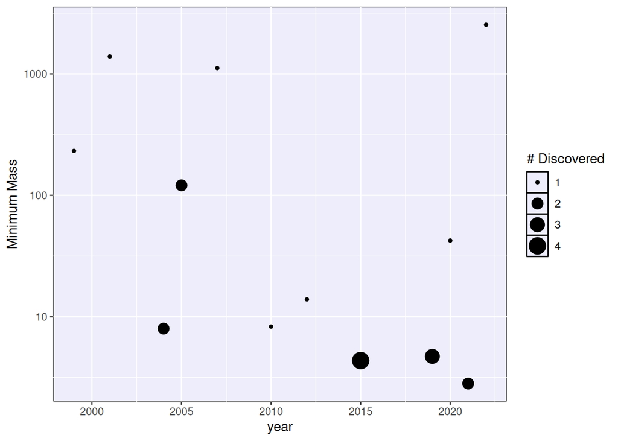

```r
ggplot(mass_by_year, aes(year, minimum_mass, size = n_discovered)) +
  geom_point() +
  scale_y_log10() +
  labs(
    y = "Minimum Mass",
    size = "# Discovered"
  )
```

# Problem 4

Starting from `planets`, the original dataframe from the top of the file, print out the planet name, mass, radius, and density of the top five most dense planets.

The density of a planet is its mass divided by its volume.

The volume of a planet is $\frac{4}{3} \times \pi \times \text{radius}^3$. Note that `pi` is a constant bult into R that you may use.

```r
planets %>%
  mutate(volume = 4/3 * pi * radius^3,
         density = mass/volume) %>%
  slice_max(density, n = 5) %>%
  select(planet, mass, radius, density)
```

```
## # A tibble: 5 × 4
##   planet          mass radius density
##   <chr>          <dbl>  <dbl>   <dbl>
## 1 KOI-4777.01    99.2   0.51    179.
## 2 Kepler-37 b     3.18  0.296    29.3
## 3 Kepler-32 b  1303     2.2      29.2
## 4 Kepler-415 b  120.    1.21     16.2
## 5 K2-77 b       604.    2.3      11.8
```

# Problem 5

Which methods are best for detecting very small planets?

Starting from `planets`,

- Keep only the rows where `radius` is not NA and is less than 40.
- Create side-by-side boxplots of the different `methods` with `radius` on the y axis. You should have five boxplots, each colored differently based on method.

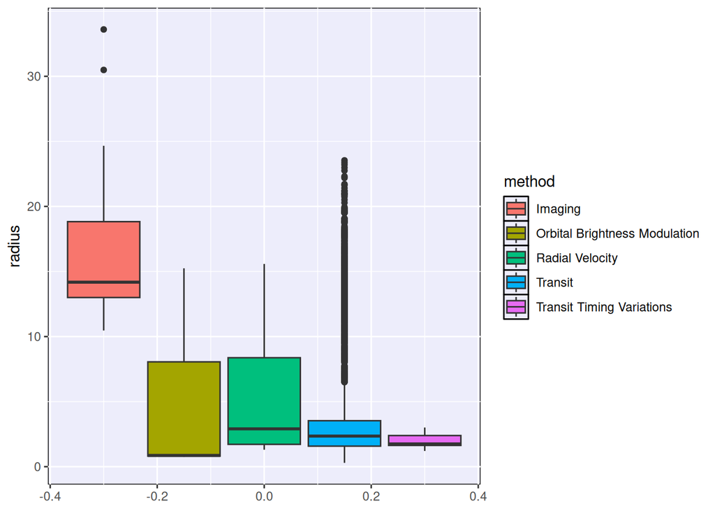

```r
planets %>%
  filter(radius < 40) %>%
  ggplot(aes(y = radius)) +
  geom_boxplot(aes(fill = method))
```

Briefly interpret the plot, keeping in mind the number of data points in each box plot is different. Which method detected the planet with the smallest radius in the dataset?

Orbital Brightness Modulation, Radial Velocity, Transit, and Transit Timing Variations are all able to detect small planets. Given that some methods have very small sample size, it is difficult to tell how similar the methods are. It seems like Imaging struggles to detect a planet with radius less than 10. Out of all of the methods, Transit detected the planet with the smallest radius.

# Problem 6

Problems 6 - 8 take you through a relatively complex analysis -> visualization process, which mimics what you might provide to a client asking the question:

“How has the most popular method of planet discovery changed over time?”

Starting from `planets`,

- Keep only the planets discovered by the `method`s “Imaging”, “Microlensing”, “Radial Velocity”, or “Transit”.
- Keep only the planets discovered in 2000 or later.
- Count how many times each remaining `method` was used within each `year`.
  - This will require you to `group_by` both `method` and `year` at the same time.
- Sort the rows such that the earliest year is first, and the most recent year is last.
- Save this dataframe with the name `methods_within_year`, and then let `methods_within_year` be printed as output so the first ten rows are visible in your .html file.

```r
methods_within_year <- planets %>%
  filter(method %in% c("Imaging", "Microlensing", "Radial Velocity", "Transit"),
         year >= 2000) %>%
  count(year, method) %>%
  arrange(year)

methods_within_year
```

```
## # A tibble: 78 × 3
##     year method              n
##    <dbl> <chr>           <int>
##  1  2000 Radial Velocity    16
##  2  2001 Radial Velocity    12
##  3  2002 Radial Velocity    28
##  4  2002 Transit             1
##  5  2003 Radial Velocity    21
##  6  2004 Imaging             3
##  7  2004 Microlensing        1
##  8  2004 Radial Velocity    18
##  9  2004 Transit             5
## 10  2005 Imaging             1
## # ℹ 68 more rows
```

The top of `methods_within_year` should look similar to this (column order does not matter).

```
# A tibble: 78 × 3
    year method              n
   <dbl> <chr>           <int>
 1  2000 Radial Velocity    16
 2  2001 Radial Velocity    12
 3  2002 Radial Velocity    28
 4  2002 Transit             1
```

# Problem 7

Starting from `methods_within_year` from problem 6 above,

- Grouping by year, add a column called `yearTotal`. `yearTotal` should indicate how many planets were discovered within that year across all methods.
  - Here’s the first four rows to check your work against:

```
    year method              n yearTotal
   <dbl> <chr>           <int>     <int>
 1  2000 Radial Velocity    16        16
 2  2001 Radial Velocity    12        12
 3  2002 Radial Velocity    28        29
 4  2002 Transit             1        29
```

- Now, add another column called `methodProportion`, which determines what percentage of the discoveries within that year were by that method.
  - Here’s what `methodProportion` should look like:

```
    year method              n yearTotal methodProportion
   <dbl> <chr>           <int>     <int>            <dbl>
 1  2000 Radial Velocity    16        16           1
 2  2001 Radial Velocity    12        12           1
 3  2002 Radial Velocity    28        29           0.966
 4  2002 Transit             1        29           0.0345
```

- Save this dataframe with the name `methods_within_year_proportions`, and then let `methods_within_year_proportions` be shown as output so the first ten rows are visible in the knitted file.

```r
methods_within_year_proportions = methods_within_year %>%
  group_by(year) %>%
  mutate(yearTotal = sum(n)) %>%
  mutate(methodProportion = n/yearTotal)

methods_within_year_proportions
```

```
## # A tibble: 78 × 5
## # Groups:   year [23]
##     year method              n yearTotal methodProportion
##    <dbl> <chr>           <int>     <int>            <dbl>
##  1  2000 Radial Velocity    16        16           1
##  2  2001 Radial Velocity    12        12           1
##  3  2002 Radial Velocity    28        29           0.966
##  4  2002 Transit             1        29           0.0345
##  5  2003 Radial Velocity    21        21           1
##  6  2004 Imaging             3        27           0.111
##  7  2004 Microlensing        1        27           0.0370
##  8  2004 Radial Velocity    18        27           0.667
##  9  2004 Transit             5        27           0.185
## 10  2005 Imaging             1        36           0.0278
## # ℹ 68 more rows
```

## Problem 8

Using `methods_within_year_proportions` from the previous question, create a column plot with `year` on the x axis and `methodProportion` on the y axis.

The height of each bar should be exactly 1. Then, use the `fill` aesthetic to color each column by its different `method`s.

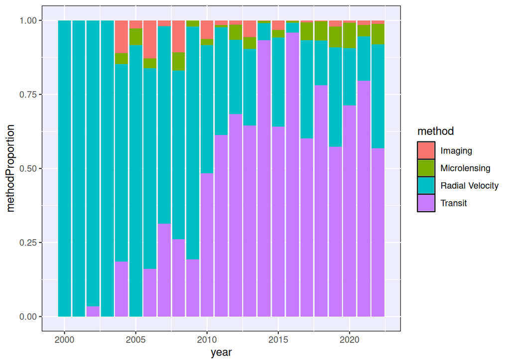

```r
ggplot(methods_within_year_proportions,
       aes(year, methodProportion, fill = method)) +
  geom_col()
```

Finally, let’s answer the client’s question. How has the most popular method of planet discovery changed over time?

Around 2000, Radial Velocity was the most popular method, but Transit began to grow in popularity and took over as the most popular method around 2010.